# How do Twitter users feel about Python and R

Catarina Silva

September 20, 2020

Python and R are popular programming languages for statistics. There is a vast amount of discussion around what’s the difference between them, which language is the best for data science and how to choose which one to learn first.

I wanted to have an overview of the Twitter community opinion behind each language. So I used *“python AND language”* and *“rstats”* for a Twitter search query for Python and R, respectively.

An interesting point I can conclude from this little exercise is that people think that both R and Python are easy (although the word “difficult” was twitted twice as much as “easy” for Python tweets and it didn’t pop up in the top words for R!).

Here is how I conducted the analysis:

**Load the packages**

```r
library("rmarkdown")
library("rtweet")
library("dplyr")
library("tidyr")
library("tidytext")
library("textdata")
library("ggplot2")
library("wordcloud2")
library("webshot")
library("htmlwidgets")
```

**Load data and process each set of tweets into tidy text**

```r
python_2020_09_19_clean = read.csv("./python_2020_09_19_clean.csv", header = T)
r_2020_09_20_clean = read.csv("./r_2020_09_20_clean.csv", header = T)

tweets_python_2020_09_19_clean = python_2020_09_19_clean %>% select(screen_name, text)
tweets_r_2020_09_20_clean = r_2020_09_20_clean %>% select(screen_name, text)
```

**Use pre-processing text transformations to clean up the tweets**

1. Remove http elements manually

```r
tweets_python_2020_09_19_clean$stripped_text1 = gsub("http\\S+","",tweets_python_2020_09_19_clean$text)

tweets_r_2020_09_20_clean$stripped_text1 = gsub("http\\S+","",tweets_r_2020_09_20_clean$text)
```

```r
tweets_python_2020_09_19_clean_stem = tweets_python_2020_09_19_clean %>%
  select(stripped_text1) %>%
  unnest_tokens(word, stripped_text1)

tweets_r_2020_09_20_clean_stem = tweets_r_2020_09_20_clean %>%
  select(stripped_text1) %>%
  unnest_tokens(word, stripped_text1)
```

3. Remove stop words from your list of words (e.g. is, on…)

```r
cleaned_tweets_python_2020_09_19_stem = tweets_python_2020_09_19_clean_stem %>%
  anti_join(stop_words)

cleaned_tweets_r_2020_09_20_stem = tweets_r_2020_09_20_clean_stem %>%
  anti_join(stop_words)
```

**Have a look at the top 40 words**

```r
top_words_tweets_python_2020_09_19 = cleaned_tweets_python_2020_09_19_stem %>%
  count(word, sort=TRUE) %>%
  top_n(40) %>%
  mutate(word = reorder(word,n))

cloud_phyton = wordcloud2(top_words_tweets_python_2020_09_19, size = 2, color = "grey", shape = "circle")
cloud_phyton
```

[interactive chart not shown]

```r
top_words_tweets_r_2020_09_20 = cleaned_tweets_r_2020_09_20_stem %>%
  count(word, sort=TRUE) %>%
  top_n(40) %>%
  mutate(word = reorder(word,n))

cloud_r = wordcloud2(top_words_tweets_r_2020_09_20, size = 1, color = "grey", shape = "circle")
cloud_r
```

[interactive chart not shown]

**Get sentiment lexicons**

```r
get_sentiments(lexicon = c("bing", "afinn", "loughran", "nrc")) %>% filter(sentiment=="positive")
get_sentiments(lexicon = c("bing", "afinn", "loughran", "nrc")) %>% filter(sentiment=="negative")

bing_python = cleaned_tweets_python_2020_09_19_stem %>%
  inner_join(get_sentiments("bing")) %>%
  count(word, sentiment, sort=TRUE) %>%
  ungroup()

bing_r = cleaned_tweets_r_2020_09_20_stem %>%
  inner_join(get_sentiments("bing")) %>%
  count(word, sentiment, sort=TRUE) %>%
  ungroup()
```

**Plot sentiment analysis for top 5 words**

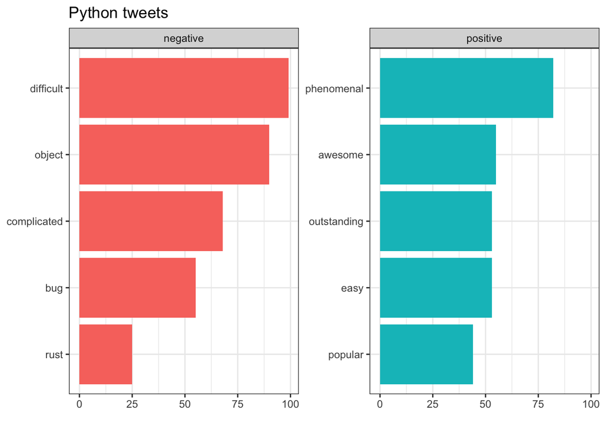

```r
bing_python %>%
  group_by(sentiment) %>%
  top_n(5) %>%
  ungroup() %>%
  mutate(word = reorder(word,n)) %>%
  ggplot(aes(word, n, fill=sentiment)) +
  geom_col(show.legend = FALSE) +
  facet_wrap(~sentiment, scales = "free_y") +
  labs(title="Python tweets",
       y="",
       x=NULL) +
  coord_flip() + theme_bw()
```

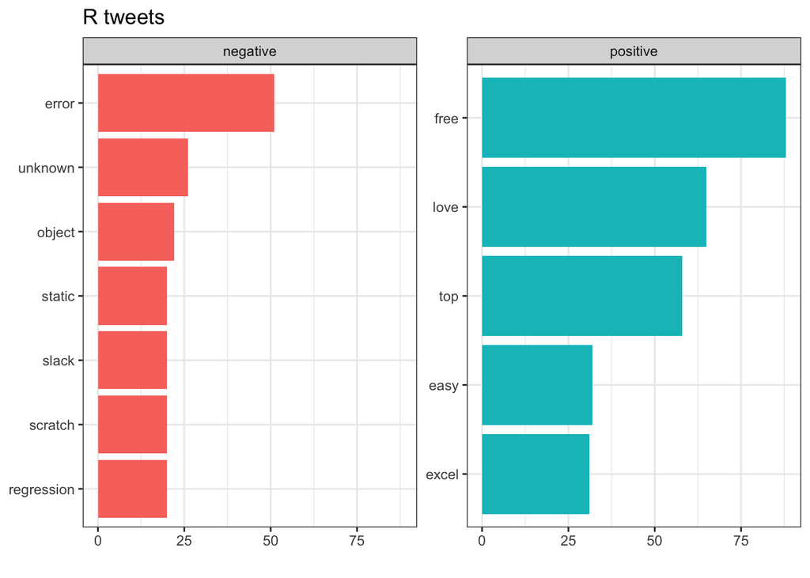

```r
bing_r %>%
  group_by(sentiment) %>%
  filter(word != "plot") %>%
  filter(word != "cloud") %>%
  filter(word != "shiny") %>%
  top_n(5) %>%
  ungroup() %>%
  mutate(word = reorder(word,n)) %>%
  ggplot(aes(word, n, fill=sentiment)) +
  geom_col(show.legend = FALSE) +
  facet_wrap(~sentiment, scales = "free_y") +
  labs(title="R tweets",
       y="",
       x=NULL) +
  coord_flip() + theme_bw()
```